# Project -3 Data 607

##### AI Publications

###### Overview

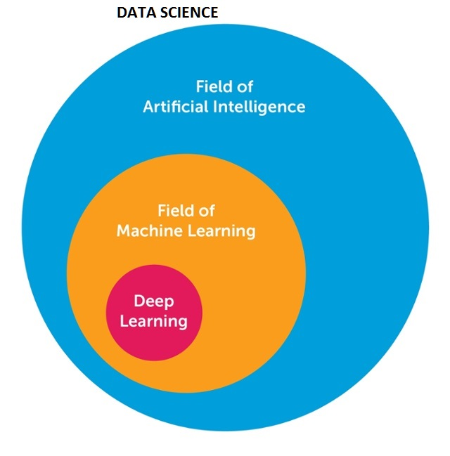

According to the Harvard Business Review, “companies with strong basic analytics - such as sales data and market trends - make breakthroughs in complex and critical areas after layering in artificial intelligence.” AI innovations like those aren’t possible without the right data and specialized data science staff who know how to use it. In 2014, about 30% of AI patents originated in the U.S, followed by South Korea and Japan, which each hold 16% of AI patents. Of the top inventor regions, South Korea and Taiwan have experienced the most growth, with the number of AI patents in 2014 nearly 5x that in 2004 . RAI is defined as the share of a country’s publication output in AI relative to the global share of publications in AI. A value of 1.0 indicates that a country’s research activity in AI corresponds exactly with the global activity in AI. A value higher than 1.0 implies a greater emphasis, while a value lower than 1.0 suggests a lesser focus.

###### Data & Import Cleansing

```r
RABR<-read.csv("https://raw.githubusercontent.com/DataScienceAR/Cuny-Assignments/master/Data-607/Data-Sets/Research_activity_by_region.csv",stringsAsFactors = FALSE)
names(RABR)<-str_replace_all(names(RABR),"X","")
RABR
```

```
##          Region 1998 1999 2000 2001 2002 2003 2004 2005 2006 2007 2008
## 1         China   8%   6%   9%  10%  12%  14%  16%  18%  20%  19%  27%
## 2 United States  28%  27%  25%  23%  24%  23%  22%  22%  19%  18%  15%
## 3        Europe  35%  35%  35%  36%  34%  35%  33%  32%  33%  33%  30%
##   2009 2010 2011 2012 2013 2014 2015 2016 2017
## 1  29%  27%  25%  24%  24%  24%  23%  24%  25%
## 2  14%  14%  15%  15%  15%  15%  18%  17%  17%
## 3  31%  31%  31%  31%  32%  31%  32%  30%  28%
```

```r
RABR<-gather(RABR,Year,Percent_of_Publications,-Region)
RABR$Percent_of_Publications<- percent(RABR$Percent_of_Publications,digits = 0)
RABR_2017<-RABR %>% filter(Year %in% c(2017,2016,2015))
```

###### Analysis & Observation

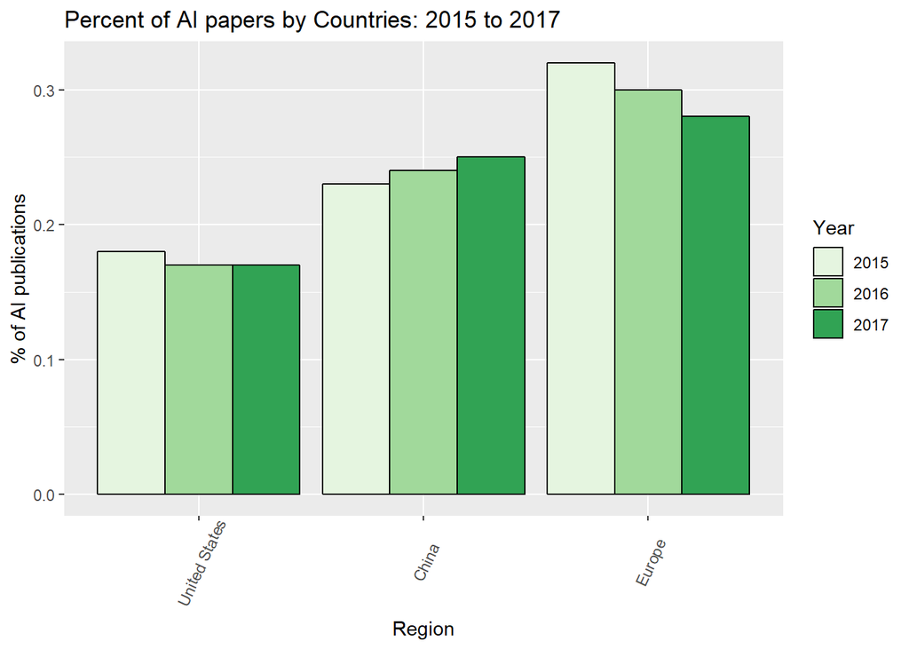

```r
ggplot(RABR_2017,aes(x=reorder(Region,Percent_of_Publications),y=Percent_of_Publications,fill=Year))+
  geom_col(position="dodge",color="black")+
  xlab("Region")+
  ylab("% of AI publications")+
  scale_fill_brewer(palette = "Dark1")+
  labs(title = "Percent of AI papers by Countries: 2015 to 2017")+
theme(axis.text.x = element_text(angle=65, vjust=0.6))
```

```r
" Europe is leading overall every year 2015 - 2017 in terms of % of AI Publications followed by China and US.
In China the trend is upward year over year although they are standing second in place"
```

###### Data & Import Cleansing

```r
RSector<-read.csv("https://raw.githubusercontent.com/DataScienceAR/Cuny-Assignments/master/Data-607/Data-Sets/Research_focus_by_Region_in_AI.csv",stringsAsFactors = FALSE)
RSector_Stg1<-gather(RSector,Country,Relative_Activity_Index,-Research.Sector)
RSector_Stg1$Country<-factor(RSector_Stg1$Country)
RSector_Stg1$Research.Sector<-factor(RSector_Stg1$Research.Sector)
RSector_Stg1<-RSector_Stg1 %>% group_by(Country) %>% mutate(label_y=cumsum(Relative_Activity_Index)-0.2*Relative_Activity_Index)
```

###### Analysis & Observation

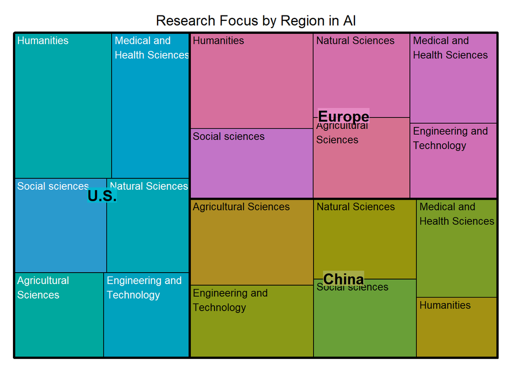

```r
library(treemap)
treemap(RSector_Stg1,index = c("Country","Research.Sector"),
        vSize = "Relative_Activity_Index",
        algorithm = "pivotSize",
        #lowerbound.cex.labels=1.6,
        title="Research Focus by Region in AI",
        fontsize.labels = c(15,10),
        align.labels = list(c("centre","centre"),c("left","top")))
```

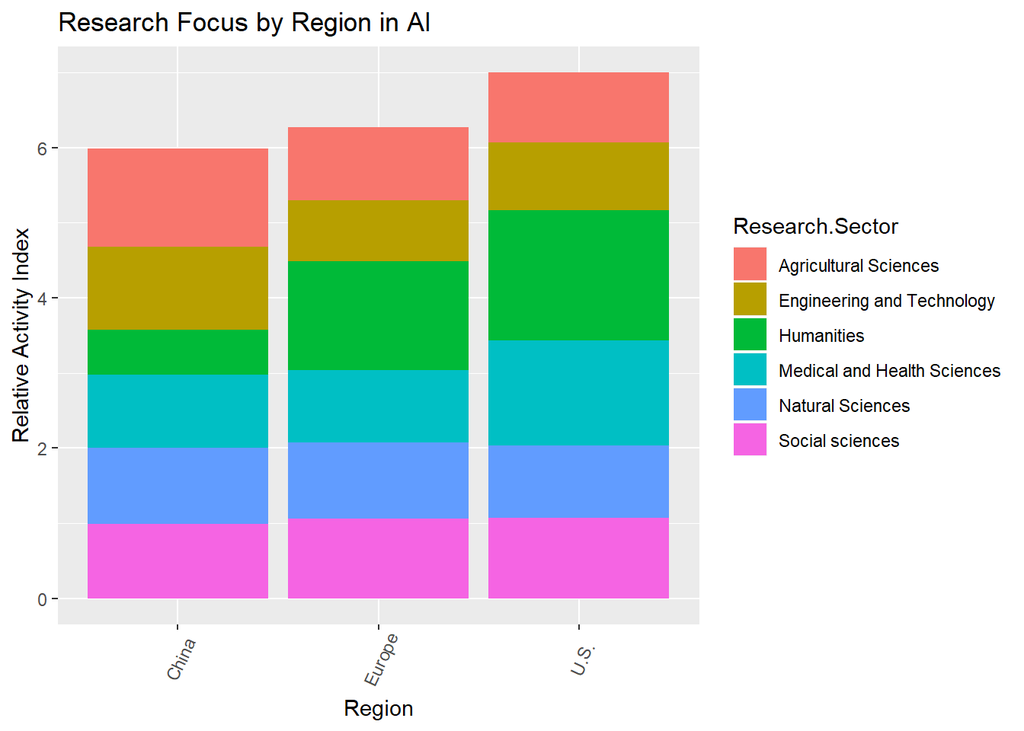

```r
ggplot(RSector_Stg1, aes(x = Country, y = Relative_Activity_Index,
                         fill = Research.Sector)) +
  geom_col() +
    xlab("Region")+
  ylab("Relative Activity Index")+
  labs(title = "Research Focus by Region in AI")+
  theme(axis.text.x = element_text(angle=65, vjust=0.6))
```

```r
"
1. United States is leading overall in terms of the research in AI but is lagging behind in Agricultural compared to Europe and China.
2. United States is leading in Humanities in AI and Medical and Health Sector of AI compared to China and Europe.
3. China is at the top position when it comes to Engineering and Technology.

"
```

### 5. Trends in Topics of interest

#### Overview

We analyze the trends in data science topics over the last decade using data from the arXiv paper repository from 2009-2018. The data suggests that all topics of data science have experienced significant nearly exponential growth. However, if we examine the topics more closely, some areas have become hotter while others have diminished on a relative basis.

###### Data Import and Cleansing

Using the arXiv research website for Data

To explore these trends, we gathered data from the arXiv research website. [Arxiv website](http://www.arxiv.org) hosts a popular and longstanding forum for academic research in mathematics, physics, statistics and computer science. Researchers submit papers electronically and are catalogued in the arxiv database.

We are able to obtain detailed research paper submission data through the R package **aRxiv** to retrieve metadata information. This API allows us to query papers based on useful criteria such as:

- submission date
- authors
- subject classification (self-described by authors)
- title of the papers

The range of dates and subject classifications below are native arXiv categories. Our tags are the same as those chosen by the AIIndex.org 2018 paper in its data collection methodology. [AIIndex 2018](http://cdn.aiindex.org/2018/AI%20Index%202018%20Annual%20Report.pdf)

```r
# A list of categories and years
# -----------------------------------------------------------------------------
ds_categories = c("stat.ML", "cs.AI", "cs.CV", "cs.LG", "cs.RO", "cs.CL", "cs.NE")
ds_descriptions = c("Stat Machine Learning", "Artificial Intelligence", "Computer Vision",
                    "Computer Learning", "Robotics", "Computation and Language" ,
                      "Neural and Evolutionary Computing")
subject_names = data.frame( categories = ds_categories ,
                            desc = ds_descriptions, stringsAsFactors = FALSE)
years_list = c( 2009:2018 )
```

```r
# Set up an empty dataframe of years range for row and data science
# topics for columns.   Values will store paper counts in arXiv by year and topic.
# ----------------------------------------------------------------------------------
info = data.frame (matrix( data = 0,
                                   nrow = length(years_list),
                                   ncol = length(ds_categories) ,
                                   dimnames = list( as.character( years_list ), ds_categories ) ) )
```

Collecting the paper counts

The following section downloads the paper counts by topic and year. Note that this step is computationally intensive and will cause an online resource restriction by the arXiv server if they feel that this query causes excessive or abusive use of computational resources.

As a result, we save the results to a local disk file. The following code chunk should set *eval* to equal *TRUE* to confirm the code works and allows downloads. Otherwise, for visualization graphics (or project final assembly), this step should be skipped. The downloaded data can be read from a file and the next code chunk. The data file is posted online.

```r
#
#  Query the arXiv server for paper counts:
#  Outer loop is on subjects
#  Inner loop is on years.
# -------------------------------------------------------------------------
for(subject in ds_categories )
{
  for( y in years_list )
  {


      qry = paste0("cat:", subject, " AND submittedDate:[",
                  y,
                  " TO ",
                  y+1, "]")

      qry_count = arxiv_count(qry)
      info[as.character(y), subject] = qry_count
      print(paste(qry, " ", qry_count, "\n"))

      # Sleeping is essential to throttle API load on the arXiv server.
      # ------------------------------------------------------------------
      Sys.sleep(3)
  }
}
#  Write the contents to files to avoid re-running the above code during
#  final project assembly
# ------------------------------------------------------------------------
write.csv(info, file="Arxiv_topic_counts.csv", row.names = TRUE)
```

And reload the paper counts here.

```r
subject_year_counts = as_tibble( read.csv("https://raw.githubusercontent.com/completegraph/DATA607PROJ3/master/Code/Arxiv_topic_counts.csv") )
```

Data Wrangling

Some minor data wrangling is needed to extract the marginal sums and fractions of annual production by topic. This is illustrated in the next code chunk.

Note that for each year in the *Period* files, the paper count is from Jan 1 of that year until Dec 31 of the same year.

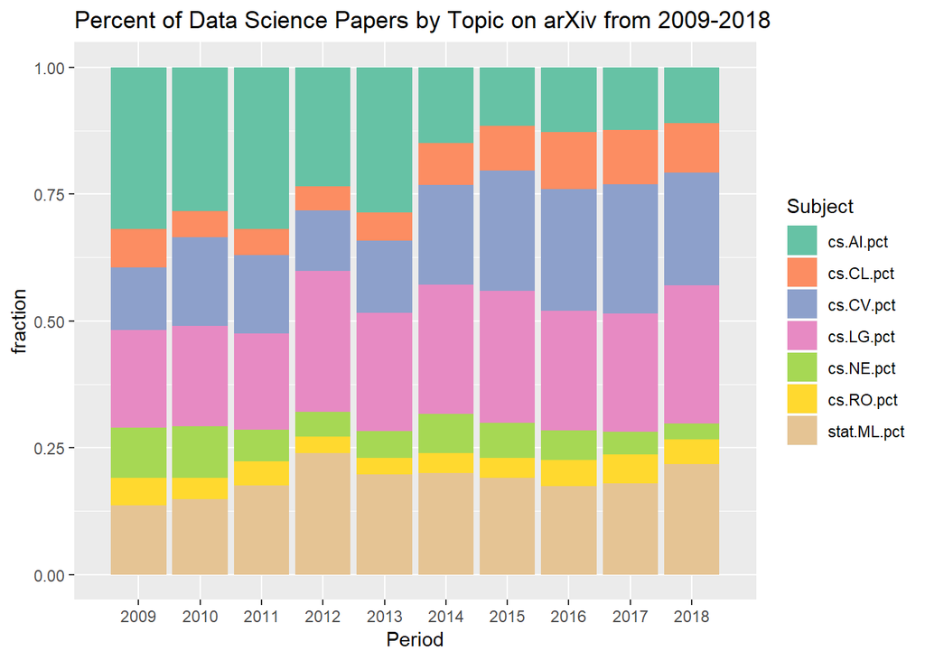

```r
# Set the names to make algebraic notation less cumbersome
# --------------------------------------------------------------------------------
names(subject_year_counts) = c("Period", as.character(subject_names$categories) )
# Calculate and store row sums
# -----------------------------------------------------------------
subject_year_counts %>%
  group_by(Period) %>%
  mutate( sum = stat.ML + cs.AI + cs.CV + cs.LG + cs.RO + cs.CL + cs.NE) %>%
  mutate( stat.ML.pct  = stat.ML / sum ,
          cs.AI.pct    = cs.AI   / sum ,
          cs.CV.pct    = cs.CV   / sum ,
          cs.LG.pct    = cs.LG   / sum ,
          cs.RO.pct    = cs.RO   / sum ,
          cs.CL.pct    = cs.CL   / sum ,
          cs.NE.pct    = cs.NE   / sum
          ) -> subject_year_counts
#
#  Plot the change in percent importance of different topics over the last 10 years
# ----------------------------------------------------------------------------------
subject_year_counts %>% select( Period, stat.ML.pct:cs.NE.pct) %>%
       gather(key="Subject", value = "fraction", stat.ML.pct:cs.NE.pct) -> pct_data
ggplot( pct_data , aes(x=Period, y = fraction, fill= Subject ) ) +
  geom_bar(stat="identity", position="fill") +
  scale_fill_brewer(palette="Set2") +
  scale_x_discrete(limits=2009:2018) +
  ggtitle("Percent of Data Science Papers by Topic on arXiv from 2009-2018")
```

```r
# Show only 2009 and 2018 statistics and merger with longer descriptions
# Then display data by year-as-column to focus on changes
# ---------------------------------------------------------------------------------
pct_data %>% filter( Period == 2009 | Period == 2018 ) %>%
    mutate( topicCode = str_sub( Subject, start= 1, end = -5), fraction = 100 * fraction) %>%
    inner_join( subject_names, by = c("topicCode" = "categories") ) %>%
    select( Period, fraction, desc ) %>%
    spread( key = Period, value = fraction ) -> table_to_show
```

The table below clearly shows significant changes in relative interest over a decade.

```r
knitr::kable(table_to_show, digit = 1 ,
             caption = "Percent Share of Articles by Topic" ) %>%
       kable_styling(bootstrap_options = c("striped", "hover"), full_width = FALSE)
```

Percent Share of Articles by Topic

| desc | 2009 | 2018 |
| --- | --- | --- |
| Artificial Intelligence | 31.9 | 11.1 |
| Computation and Language | 7.6 | 9.7 |
| Computer Learning | 19.2 | 27.2 |
| Computer Vision | 12.3 | 22.3 |
| Neural and Evolutionary Computing | 9.9 | 3.1 |
| Robotics | 5.4 | 4.8 |
| Stat Machine Learning | 13.6 | 21.8 |

Trends in the Total Volume of Research

The evidence below will show exponential growth in data science research. Statistic and machine learning and computer vision are driving the bulk of this work.

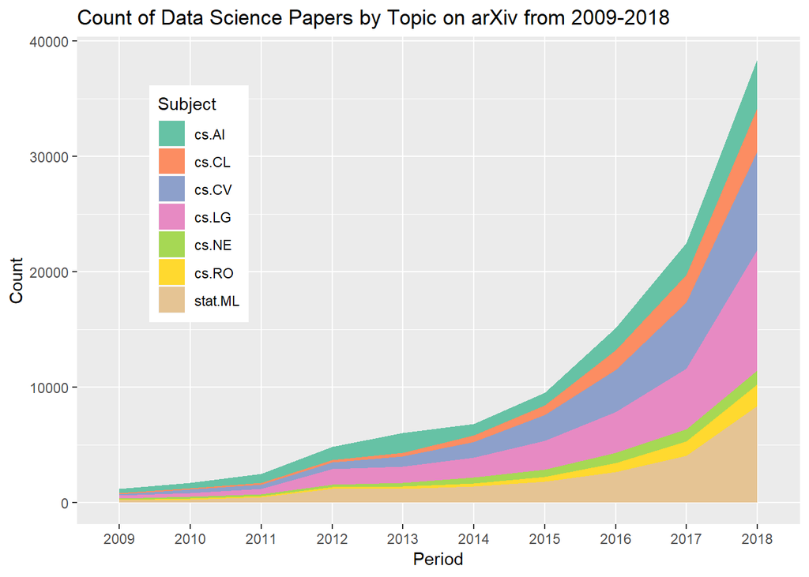

```r
#
# Plot the change in absolute papers submitted
# -----------------------------------------------------------------
subject_year_counts %>% select( Period, stat.ML:cs.NE) %>%
  gather(key="Subject", value = "Count", stat.ML:cs.NE) -> abs_data
ggplot( abs_data , aes(x=Period, y = Count, fill= Subject ) ) +
  geom_area() +
  scale_fill_brewer(palette="Set2") +
  scale_x_discrete(limits=2009:2018) +
  ggtitle("Count of Data Science Papers by Topic on arXiv from 2009-2018") +
  theme(legend.position= c(.1, .9 ),
        legend.justification = c("left", "top"))
```

Explosive Growth of Research

```r
knitr::kable(subject_year_counts %>% select( Period, sum ) %>% spread( key = Period, value = sum ) ,
             caption = "Total Data Science Articles on Arxiv by Year" ) %>%
       kable_styling(bootstrap_options = c("striped", "hover"), full_width = FALSE)
```

Total Data Science Articles on Arxiv by Year

| 2009 | 2010 | 2011 | 2012 | 2013 | 2014 | 2015 | 2016 | 2017 | 2018 |
| --- | --- | --- | --- | --- | --- | --- | --- | --- | --- |
| 1197 | 1679 | 2460 | 4819 | 6032 | 6815 | 9528 | 15124 | 22492 | 38433 |

A simple calculation from the above table allows us toconclude that the volume of research (by article count) has grown 47 percent annually. This explosive growth in research has resulted in a 32 fold increase in research in the most recent decade. Whether the quality matches the quantity is another issue. But this is compelling supporting evidence that artificial intelligence is revolutionizing academic research and thought leadership.

### 6. Academia: Top Ranked Universities in AI, ML or DS

#### Introduction and Analysis

The section below loads the required packages and input data files containing the following details of research papers in Artificial Intelligence (AI), Data Science (DS), Machine Learning (ML), Visualization (VI): Names of faculty members who authored these papers, universities they’re affiliated to, conferences they presented at, and the year of publication. The conferences selected were restricted to those in the above fields only.

```r
fileurl<-"https://raw.githubusercontent.com/completegraph/DATA607PROJ3/master/Code/author-info-ds.csv"
ds.authors<-read.csv(file=fileurl, header=TRUE, na.strings = "NA", stringsAsFactors = TRUE)
#ds.authors<-fread(fileurl, header=TRUE, na.strings = "NA", stringsAsFactors = FALSE)
#ds.authors
```

The section below filters the data for the 2 main columns of interest: University and Adjusted Count. The adjusted count is a score that measures contribution by authors based on joint ownership with other authors. The detailed methodology is available at http://csrankings.org/#/index?all

The analysis below aims to determine which university across the globe, can be deemed to be a thought leader in the Data Science, Artificial Intelligence, Machine Learning and Visualization areas, based on the contribution of their faculty members by writing research papers.

The following section selects the required columns, and calculates an aggregate of the adjusted count by university.Then it renames the columns, and derives the top 10 universities based on this adjusted count metric.

```r
paper.count<-ds.authors%>%select(university,adjustedcount)
summary.paper.count<-aggregate(. ~ university, data = paper.count, sum)%>%setorder(-adjustedcount)
summary.paper.count$adjustedcount<-round(summary.paper.count$adjustedcount,2)
colnames(summary.paper.count)<-c("University", "Research_Adj_Count")
#summary.paper.count
top10<-summary.paper.count[1:10,]
top10
```

```
##                                University Research_Adj_Count
## 26             Carnegie Mellon University             515.84
## 254   University of California - Berkeley             250.29
## 352                   University of Tokyo             239.10
## 65        Georgia Institute of Technology             204.46
## 122 Massachusetts Institute of Technology             200.75
## 338     University of Southern California             198.27
## 328            University of Pennsylvania             194.29
## 242                 University of Alberta             173.05
## 212                             TU Munich             172.86
## 38                     Cornell University             167.04
```

The following section generates a barplot showing the top 10 universities by adjusted count of research papers. It shows that Carnegie Mellon sits at the top of the stack by a big margin. So it can considered as the prime thought leader from an institutional perspective.

As a topic for further research, it is notable that a big name like Stanford University is missing from the top 10 universities. We suspect that this could be on account of factors like departmental affiliations of faculty members and their choices on whether to present their research at pure Data Science type conferences vis-a-vis other conferences geared towards other domains such as Statistics or Economics. Also, it’s likely that if the focus is extended to all of Computer Science instead of a narrower selection of AI, DS, ML etc, then universities like Stanford may show a more significant presence while perhaps the universities in the top 10 are more exclusively focusing on AI, ML and DS research.

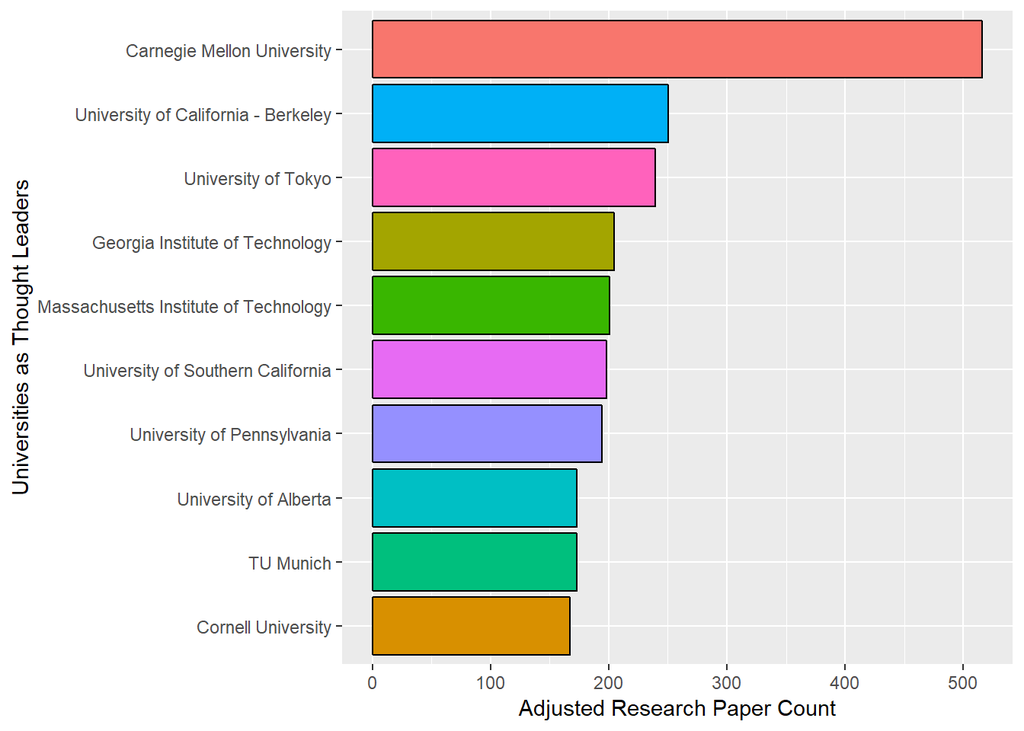

```r
library(ggplot2)
library(RColorBrewer)
ggplot(top10, aes(x=reorder(University,Research_Adj_Count), y=Research_Adj_Count, fill=University))+ geom_bar(stat="identity",color="black") + coord_flip() + theme(legend.position='none') + ylab("Adjusted Research Paper Count") + xlab("Universities as Thought Leaders")
```

##### Trends in Data Science sub-topics as evidenced by change in research paper counts over the years

From the data and graph below, it can be seen that Machine Learning, Neural Networks and Computer Visualization are showing a very rapid growth in research publications.

```r
fileurl3<-"https://raw.githubusercontent.com/completegraph/DATA607PROJ3/master/Code/AIPapersByTopic.csv"
ai.subtopics<-read.csv(fileurl3)
colnames(ai.subtopics)<-c("Year", "Machine Learning", "Neural Networks", "Computer Vision", "Search optimization", "NLP", "Fuzzy Systems", "Decision Making", "Total")
ai.subtopics
```

```
##    Year Machine Learning Neural Networks Computer Vision
## 1  1998             4319            4680            3460
## 2  1999             4826            5569            3868
## 3  2000             4636            5383            4087
## 4  2001             5191            5659            4430
## 5  2002             6189            6320            5366
## 6  2003             7325            6819            6186
## 7  2004            10256            8590            8132
## 8  2005            11743            9520            9274
## 9  2006            13068           10487           10670
## 10 2007            15453           11594           12849
## 11 2008            19786           14454           16942
## 12 2009            16699           14270           14041
## 13 2010            17122           14302           14298
## 14 2011            16962           13853           14193
```

[output cut: 27 more lines]

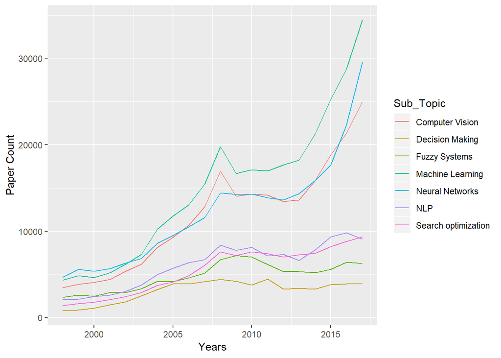

```r
ai.subtopics.long<-gather(ai.subtopics, key="Sub_Topic", value=Paper_Count, 2:8)
ggplot(ai.subtopics.long, aes(x=Year, y=Paper_Count, group=Sub_Topic,colour=Sub_Topic)) + geom_line()+xlab("Years")+ylab("Paper Count")
```

##### Percentage of AI and ML course enrollments in US Universities at the Undergraduate Level

```r
fileurl2<-"https://raw.githubusercontent.com/completegraph/DATA607PROJ3/master/Code/USAI-MLUndergradEnrolmentPercentage.csv"
undergrad<-read.csv(fileurl2)
colnames(undergrad)<-c("University", "Domain", "2010", "2011", "2012", "2013", "2014", "2015", "2016", "2017")
#undergrad
undergrad.long<-gather(undergrad, key="Year", value=Percent_Share, 3:10)
undergrad.long$UnivDomain=paste(undergrad.long$University, undergrad.long$Domain, sep="-")
undergrad.long$Percent_Share=round(undergrad.long$Percent_Share*100,2)
undergrad.long
```

```
##    University Domain Year Percent_Share  UnivDomain
## 1    Berkeley     AI 2010             2 Berkeley-AI
## 2    Stanford     AI 2010             3 Stanford-AI
## 3        UIUC     AI 2010             1     UIUC-AI
## 4          UW     AI 2010             0       UW-AI
## 5    Berkeley     ML 2010             0 Berkeley-ML
## 6    Stanford     ML 2010             5 Stanford-ML
## 7        UIUC     ML 2010             0     UIUC-ML
## 8          UW     ML 2010             0       UW-ML
## 9    Berkeley     AI 2011             2 Berkeley-AI
## 10   Stanford     AI 2011             3 Stanford-AI
## 11       UIUC     AI 2011             0     UIUC-AI
## 12         UW     AI 2011             0       UW-AI
## 13   Berkeley     ML 2011             0 Berkeley-ML
## 14   Stanford     ML 2011             5 Stanford-ML
```

[output cut: 50 more lines]

The following graph shows the academic enrolment at the undergraduate level in AI and ML courses in selected US universities, over the 2010-2017 period. From this, it can be seen that academic enrolment has been trending up over the past few years in these universities, which can be seen as representative across all US universities.

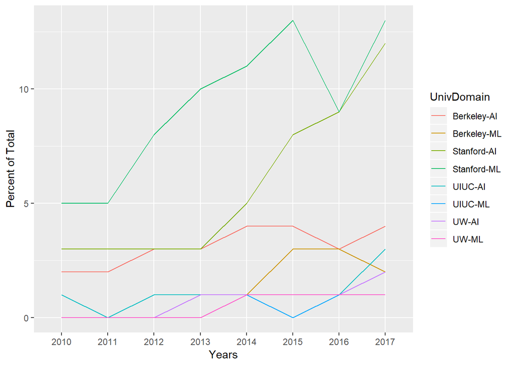

```r
library(ggplot2)
ggplot(undergrad.long, aes(x=Year, y=Percent_Share, group=UnivDomain,colour=UnivDomain)) + geom_line()+xlab("Years")+ylab("Percent of Total")
```

##### Regions and Countries as Thought Leaders

The following section collects the inputs: regional percentage share of Artificial Intelligence publications over the 1998-2017 period. The data is loaded and tidied from a wide format to a long format, setting it up for further analysis.

```r
fileurl<-"https://raw.githubusercontent.com/completegraph/DATA607PROJ3/master/Code/RegionalShareofAIPublications.csv"
regional.ai<-read.csv(fileurl)
colnames(regional.ai)<-c("Region","1998","1999","2000","2001","2002","2003","2004","2005","2006","2007","2008","2009","2010","2011", "2012","2013","2014","2015","2016","2017")
#regional.ai
regional.ai.long<-gather(regional.ai, key="Year", value=Percentage_Share, 2:21)
regional.ai.long
```

```
##           Region Year Percentage_Share
## 1          China 1998             0.08
## 2  United States 1998             0.28
## 3         Europe 1998             0.35
## 4  Rest of World 1998             0.28
## 5          China 1999             0.06
## 6  United States 1999             0.27
## 7         Europe 1999             0.35
## 8  Rest of World 1999             0.32
## 9          China 2000             0.09
## 10 United States 2000             0.25
## 11        Europe 2000             0.35
## 12 Rest of World 2000             0.31
## 13         China 2001             0.10
## 14 United States 2001             0.23
```

[output cut: 66 more lines]

##### Countries as Thought Leaders

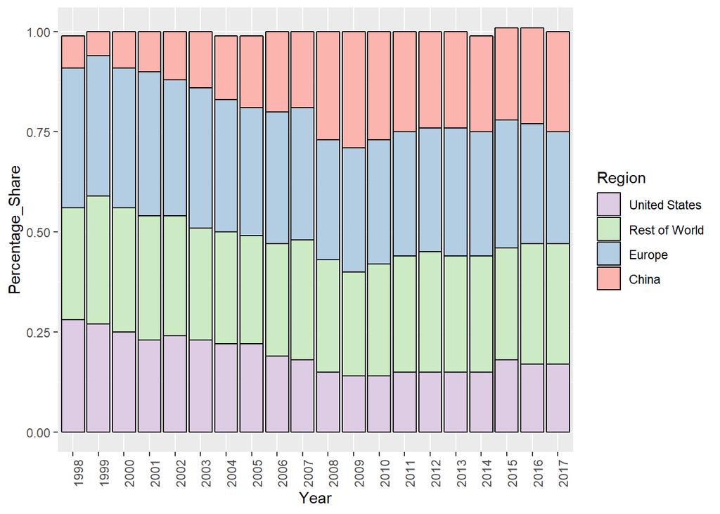

```r
ggplot(regional.ai.long, aes(x=Year, y=Percentage_Share, fill=Region)) +
geom_bar(stat="identity", colour="black") +
guides(fill=guide_legend(reverse=TRUE)) +
scale_fill_brewer(palette="Pastel1") + theme(text = element_text(size=11),axis.text.x = element_text(angle=90, hjust=1))
```

### 7. Conclusion

Based on popular narrative, Andrew Ng and Kira Radinsky can be considered to be two of the primary thought leaders in Data Science. Over the pasy few years, they have shifted their focus from AI to more specific topics of specialisations such as deep learning, predictive analytics, and speech recognition.

We conclude that the top influential data scientist by paper count is Yoshua Bengio with 174 papers. He is noted for his expertise in deep learning along with Geoffrey Hinton and Yann LeCun. We conclude that thought leadership within the field of academic research does not equate to business thought leadership. However, without conceptual innovations made possible by academia, the application of these ideas to business is impossible.

When it comes to countries and regions, the USA leads in terms of patents in DS/AI/ML, while Europe leads in terms of generating research publications. China is catching up rapidly - for example Tsingshua University led the way in terms of research papers in this domain during 2018. Universities in the USA are showing a steady increase in enrolment in AI/ML courses, and Carnegie Melon continutes to lead the way in research in this domain.

We relied on a variety of sources for the data used in our analysis, such as the AI Index Report for 2018, the CS Rankings, aRxiv and ACM websites, as well as personal websites of individuals such as Andrew Ng. In terms of future research, we think that understanding what’s driving the changes in topics of interest for popular data science professionals as well as academia would be a good area to focus on.